# FigureYa52 GOplot

## Enrichment analysis

Reference materials:< http://bioconductor.org/packages/release/bioc/vignettes/clusterProfiler/inst/doc/clusterProfiler.html#supported -organisms>

If you have already completed the enrichment analysis and saved it in the format of “enrichGO_output. csv”, you can skip this part and directly enter “Convert the enrichment analysis results output by clusterProfiler to the format required by GOplot”

```r
# 读取ENTREZ ID和log2折叠变化数据 | Read ENTREZ ID and log2 fold change data
# 假设ENTREZ ID位于第一列，log2foldchange位于第二列 | Assume ENTREZ ID is in the first column and log2foldchange in the second column
id.fc <- read.csv("very_easy_input_Mm.csv", as.is = T)
# 查看数据前几行 | View the first few rows of the data
head(id.fc)
```

```
##   ENTREZID    log2fc
## 1    11990 -0.308724
## 2    12290 -0.352114
## 3    12291 -0.300020
## 4    12334 -0.199424
## 5    12552 -0.206564
## 6    12561 -0.500161
```

```r
# 查看数据维度 | Check the dimensions of the data
dim(id.fc)
```

```
## [1] 201   2
```

```r
# 进行基因本体论(GO)富集分析 | Perform Gene Ontology (GO) enrichment analysis
ego <- enrichGO(gene = id.fc$ENTREZID,         # 输入的基因列表(ENTREZ ID) | Input gene list (ENTREZ IDs)
                # 选择物种注释数据库 - 小鼠使用此行 | Select species annotation database - use this line for mouse
                OrgDb = org.Mm.eg.db,
                # 人类使用此行 | Use this line for human
                #OrgDb = org.Hs.eg.db,
                # 非模式生物使用此行，例如玉米 | Use this line for non-model organisms like maize
                #OrgDb = maize.db,
                ont = "BP",                   # 选择GO分类: BP(生物学过程)、MF(分子功能)或CC(细胞组分) | Select GO ontology: BP (Biological Process), MF (Molecular Function), or CC (Cellular Component)
                pAdjustMethod = "BH",         # p值校正方法为Benjamini-Hochberg | P-value adjustment method: Benjamini-Hochberg
                #pvalueCutoff  = 0.001,      # 原始p值阈值(注释掉未使用) | Raw p-value cutoff (commented out)
                qvalueCutoff  = 0.01)        # 校正后q值阈值 | Adjusted q-value cutoff
# 查看富集结果的维度 | Check the dimensions of the enrichment results
dim(ego)
```

```
## [1] 334  12
```

```r
# 将富集分析结果保存为CSV文件 | Save the enrichment analysis results to a CSV file
write.csv(ego, "enrichGO_output.csv", quote = F)  # 不使用引号包裹字段 | Do not quote fields
```

富集的GO term有些是相似的，可以用语义学方法，合并相似的GO term。需要较长时间。

参考资料：https://guangchuangyu.github.io/2015/10/use-simplify-to-remove-redundancy-of-enriched-go-terms/

Some enriched GO terms are similar, and semantic methods can be used to merge similar GO terms. It takes a long time.

Reference materials:< https://guangchuangyu.github.io/2015/10/use-simplify-to-remove-redundancy-of-enriched-go-terms/ >

```r
# 可选：简化富集结果，减少冗余 | Optional: Simplify enrichment results to reduce redundancy
# ego2 <- simplify(ego, cutoff = 0.7, by = "p.adjust", select_fun = min)
# 查看简化后的结果维度 | Check dimensions of simplified results
# dim(ego2)
# 将简化后的富集分析结果保存为CSV文件 | Save simplified enrichment results to CSV file
# write.csv(ego2, "enrichGO_simplify_output.csv", quote = F)
```

用enrichplot自带的函数画⭕️

参考资料：https://bioconductor.org/packages/release/bioc/vignettes/enrichplot/inst/doc/enrichplot.html

Draw using the built-in functions of enrichplot ⭕ ️

Reference materials:< https://bioconductor.org/packages/release/bioc/vignettes/enrichplot/inst/doc/enrichplot.html >

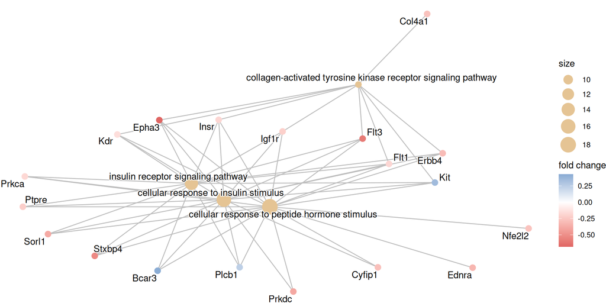

```r
# 将ENTREZ ID转换为基因符号，提高结果可读性 | Convert ENTREZ IDs to gene symbols for better readability
egox <- setReadable(ego, 'org.Mm.eg.db', # 选择物种注释数据库 | Select species annotation database
                    'ENTREZID')           # 指定输入的ID类型为ENTREZ ID | Specify input ID type as ENTREZ ID

# 准备基因表达量数据，用于可视化 | Prepare gene expression data for visualization
geneList <- id.fc$log2fc                  # 提取log2折叠变化值 | Extract log2 fold change values
names(geneList) <- id.fc$ENTREZID         # 设置基因列表的名称为ENTREZ ID | Set names of the gene list to ENTREZ IDs

# 绘制基因-功能富集网络环形图 | Plot circular gene-function enrichment network
cnetplot(egox,
         foldChange = geneList,           # 显示基因表达量变化 | Show gene expression fold change
         #foldChange = NULL,             # 不展示表达量变化(注释掉) | Do not show fold change (commented out)
         circular = TRUE,                 # 设置为环形布局 | Set circular layout
         #node_label = FALSE,            # 如果基因太多，可关闭基因名显示(注释掉) | Hide gene names if too many (commented out)
         showCategory = 4,                # 显示富集的term数量 | Number of enriched terms to display
         colorEdge = TRUE)                # 按关系类型着色边 | Color edges by relationship type
```

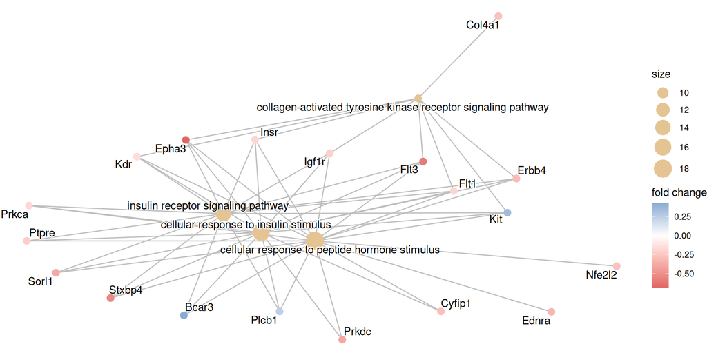

```r
# 将环形图保存为PDF文件 | Save circular plot to PDF file
ggsave("clusterProfiler_circle.pdf", width = 8, height = 5)

# 绘制基因-功能富集网络图(非环形) | Plot non-circular gene-function enrichment network
cnetplot(egox,
         foldChange = geneList,           # 显示基因表达量变化 | Show gene expression fold change
         #foldChange = NULL,             # 不展示表达量变化(注释掉) | Do not show fold change (commented out)
         #circular = TRUE,               # 关闭环形布局(注释掉) | Disable circular layout (commented out)
         #node_label = FALSE,            # 不显示基因名(注释掉) | Hide gene names (commented out)
         showCategory = 4,                # 显示富集的term数量 | Number of enriched terms to display
         colorEdge = TRUE)                # 按关系类型着色边 | Color edges by relationship type
```

```r
# 将非环形图保存为PDF文件 | Save non-circular plot to PDF file
ggsave("clusterProfiler_not_circle.pdf", width = 8, height = 5)
```

## 把clusterProfiler输出的富集分析结果转成GOplot所需的格式

## Convert the enrichment analysis results output by clusterProfiler into the format required by GOplot

```r
# 读取富集分析结果 | Read enrichment analysis results
ego <- read.csv("enrichGO_output.csv", header = T)
# 查看第一行数据 | View the first row of data
ego[1,]
```

```
##            X         ID                        Description GeneRatio   BgRatio
## 1 GO:0008286 GO:0008286 insulin receptor signaling pathway    14/194 194/28832
##   RichFactor FoldEnrichment   zScore       pvalue    p.adjust       qvalue
## 1 0.07216495       10.72505 11.18615 6.407247e-11 1.72459e-07 1.165536e-07
##                                                                                geneID
## 1 13837/13869/14254/14255/16001/16337/16542/18750/19267/20660/20913/29815/18795/16590
##   Count
## 1    14
```

```r
# 准备GO富集结果数据框 | Prepare data frame for GO enrichment results
go <- data.frame(Category = "BP",               # 设置类别为生物学过程(Biological Process) | Set category to Biological Process
                 ID = ego$ID,                    # GO条目ID | GO term ID
                 Term = ego$Description,         # GO条目描述 | GO term description
                 Genes = gsub("/", ", ", ego$geneID), # 将基因ID分隔符从斜杠改为逗号 | Replace gene ID separator from '/' to ', '
                 adj_pval = ego$p.adjust)        # 校正后的p值 | Adjusted p-value

# 读取基因表达量变化数据 | Read gene expression fold change data
id.fc <- read.csv("very_easy_input_Mm.csv", as.is = T)
# 查看数据前几行 | View the first few rows of data
head(id.fc)
```

```
##   ENTREZID    log2fc
## 1    11990 -0.308724
## 2    12290 -0.352114
## 3    12291 -0.300020
## 4    12334 -0.199424
## 5    12552 -0.206564
## 6    12561 -0.500161
```

```r
# 创建基因表达量数据框 | Create data frame for gene expression
genelist <- data.frame(ID = id.fc$ENTREZID, logFC = id.fc$log2fc)

# 整合富集分析结果与表达量变化数据 | Integrate enrichment results with expression data
circ <- circle_dat(go, genelist)
# 查看整合后数据前几行 | View the first few rows of integrated data
head(circ)
```

```
##   category         ID                               term count genes     logFC
## 1       BP GO:0008286 insulin receptor signaling pathway    14 13837 -0.681811
## 2       BP GO:0008286 insulin receptor signaling pathway    14 13869 -0.301868
## 3       BP GO:0008286 insulin receptor signaling pathway    14 14254 -0.183248
## 4       BP GO:0008286 insulin receptor signaling pathway    14 14255 -0.594008
## 5       BP GO:0008286 insulin receptor signaling pathway    14 16001 -0.213881
## 6       BP GO:0008286 insulin receptor signaling pathway    14 16337 -0.182849
##      adj_pval   zscore
## 1 1.72459e-07 -2.13809
## 2 1.72459e-07 -2.13809
## 3 1.72459e-07 -2.13809
## 4 1.72459e-07 -2.13809
## 5 1.72459e-07 -2.13809
## 6 1.72459e-07 -2.13809
```

```r
# 将ENTREZ ID转换为基因符号 | Convert ENTREZ IDs to gene symbols
id.gsym <- bitr(circ$genes,                    # 基因ID列 | Gene ID column
                fromType = "ENTREZID",          # 输入ID类型为ENTREZ ID | Input ID type: ENTREZ ID
                toType = "SYMBOL",             # 输出ID类型为基因符号 | Output ID type: gene symbol
                OrgDb = "org.Mm.eg.db")        # 小鼠注释数据库 | Mouse annotation database
# 将整合数据中的ENTREZ ID替换为基因符号 | Replace ENTREZ IDs with gene symbols in integrated data
rownames(id.gsym) <- id.gsym$ENTREZID          # 设置行名为ENTREZ ID | Set row names to ENTREZ IDs
circ.gsym <- circ                               # 创建副本 | Create a copy
circ.gsym$genes <- id.gsym[circ$genes,]$SYMBOL # 替换基因为符号 | Replace genes with symbols
# 查看替换后数据前几行 | View the first few rows of updated data
head(circ.gsym)
```

```
##   category         ID                               term count genes     logFC
## 1       BP GO:0008286 insulin receptor signaling pathway    14 Epha3 -0.681811
## 2       BP GO:0008286 insulin receptor signaling pathway    14 Erbb4 -0.301868
## 3       BP GO:0008286 insulin receptor signaling pathway    14  Flt1 -0.183248
## 4       BP GO:0008286 insulin receptor signaling pathway    14  Flt3 -0.594008
## 5       BP GO:0008286 insulin receptor signaling pathway    14 Igf1r -0.213881
## 6       BP GO:0008286 insulin receptor signaling pathway    14  Insr -0.182849
##      adj_pval   zscore
## 1 1.72459e-07 -2.13809
## 2 1.72459e-07 -2.13809
## 3 1.72459e-07 -2.13809
## 4 1.72459e-07 -2.13809
## 5 1.72459e-07 -2.13809
## 6 1.72459e-07 -2.13809
```

```r
# 使用GOplot包进行可视化（示例代码，未执行） | Visualization examples using GOplot (not executed)
# GOBar(subset(circ, category == 'BP'))         # 绘制BP类别的柱状图 | Bar plot for BP category
# GOBubble(circ, labels = 3)                    # 绘制气泡图 | Bubble plot
# GOCircle(circ)                                 # 绘制环形图 | Circular plot
```

## 用GOplot画⭕️图

参考资料：http://wencke.github.io/

准备画⭕️图所需的数据格式

##Draw with GOplot ⭕ ️ Image

Reference materials:< http://wencke.github.io/ >

Prepare to draw ⭕ The required data format for the image

```r
# 参数设置 | Parameter settings
n = 5 # 圈图需要选定term，这里画前面5个 | Select the top 5 enriched terms for chord diagram

# 准备弦图数据 | Prepare data for chord diagram
chord <- chord_dat(circ, genelist, go$Term[1:n])
# 查看数据前几行 | View the first few rows of the data
head(chord)
```

```
##       insulin receptor signaling pathway cellular response to insulin stimulus
## 11990                                  0                                     0
## 12561                                  0                                     0
## 12826                                  0                                     0
## 13052                                  0                                     0
## 13837                                  1                                     1
## 13869                                  1                                     1
##       collagen-activated tyrosine kinase receptor signaling pathway
## 11990                                                             0
## 12561                                                             0
## 12826                                                             1
## 13052                                                             0
## 13837                                                             1
## 13869                                                             1
##       cellular response to peptide hormone stimulus
## 11990                                             0
## 12561                                             0
## 12826                                             0
## 13052                                             0
## 13837                                             1
## 13869                                             1
##       regulation of developmental growth     logFC
## 11990                                  1 -0.308724
## 12561                                  1 -0.500161
## 12826                                  0 -0.274203
## 13052                                  1 -0.200243
## 13837                                  0 -0.681811
## 13869                                  1 -0.301868
```

```r
# 将ENTREZ ID转换为基因符号 | Convert ENTREZ IDs to gene symbols
id.gsym <- bitr(row.names(chord),          # 基因ID列 | Column containing gene IDs
                fromType = "ENTREZID",      # 输入ID类型为ENTREZ ID | Input ID type: ENTREZ ID
                toType = "SYMBOL",         # 输出ID类型为基因符号 | Output ID type: gene symbol
                OrgDb = "org.Mm.eg.db")    # 小鼠注释数据库 | Mouse annotation database
# 将chord数据框中的ENTREZ ID行名替换为基因符号 | Replace row names (ENTREZ IDs) with gene symbols
rownames(id.gsym) <- id.gsym$ENTREZID      # 设置行名为ENTREZ ID | Set row names to ENTREZ IDs
# 查看转换结果前几行 | View the first few rows of the conversion result
head(id.gsym)
```

```
##       ENTREZID SYMBOL
## 11990    11990   Atrn
## 12561    12561   Cdh4
## 12826    12826 Col4a1
## 13052    13052  Cxadr
## 13837    13837  Epha3
## 13869    13869  Erbb4
```

```r
chord.gsym <- chord                        # 创建数据框副本 | Create a copy of the data frame
row.names(chord.gsym) <- id.gsym[row.names(chord),]$SYMBOL  # 替换行为基因符号 | Replace row names with gene symbols
# 查看替换后数据前几行 | View the first few rows of the updated data
head(chord.gsym)
```

```
##        insulin receptor signaling pathway cellular response to insulin stimulus
## Atrn                                    0                                     0
## Cdh4                                    0                                     0
## Col4a1                                  0                                     0
## Cxadr                                   0                                     0
## Epha3                                   1                                     1
## Erbb4                                   1                                     1
##        collagen-activated tyrosine kinase receptor signaling pathway
## Atrn                                                               0
## Cdh4                                                               0
## Col4a1                                                             1
## Cxadr                                                              0
## Epha3                                                              1
## Erbb4                                                              1
##        cellular response to peptide hormone stimulus
## Atrn                                               0
## Cdh4                                               0
## Col4a1                                             0
## Cxadr                                              0
## Epha3                                              1
## Erbb4                                              1
##        regulation of developmental growth     logFC
## Atrn                                    1 -0.308724
## Cdh4                                    1 -0.500161
## Col4a1                                  0 -0.274203
## Cxadr                                   1 -0.200243
## Epha3                                   0 -0.681811
## Erbb4                                   1 -0.301868
```

用⭕️图展示每个term里的基因及其变化倍数

use ⭕ The figure displays the genes and their fold changes in each term

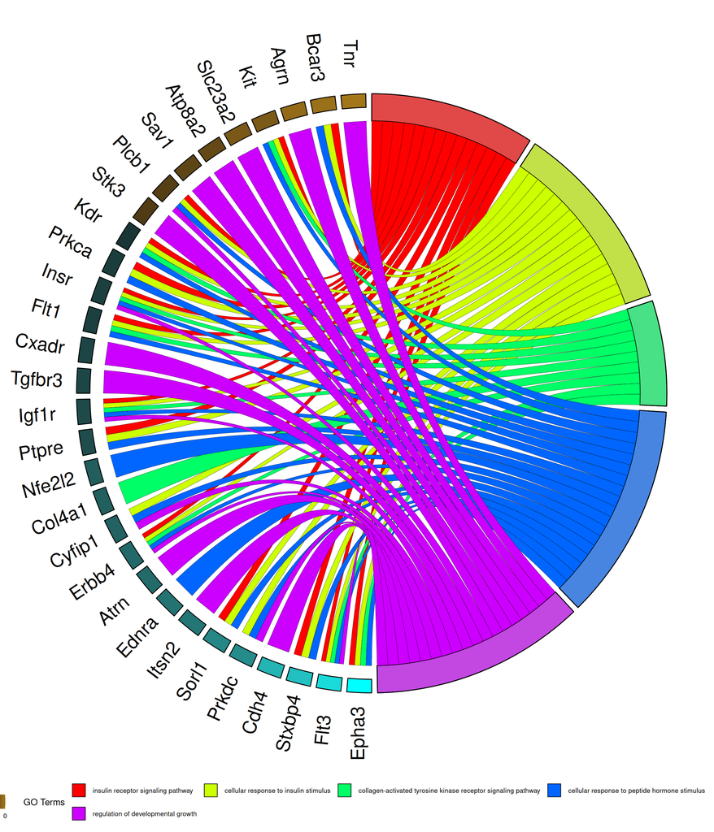

```r
# 绘制基因与GO术语关联的弦图 | Plot chord diagram showing gene-GO term associations
GOChord(chord.gsym,
        space = 0.02,           # 基因方块之间的间隙大小 | Gap between gene blocks
        gene.order = 'logFC',   # 按log2折叠变化值排序基因 | Order genes by log2 fold change
        lfc.col = c('darkgoldenrod1', 'black', 'cyan1'),  # 自定义表达量变化的颜色映射 | Custom color palette for fold change
        gene.space = 0.25,      # 基因名称与圆环的相对距离 | Distance between gene names and circle
        gene.size = 8,          # 基因名称的字体大小 | Font size for gene names
        border.size = 0.1,      # 中间连接线黑色边框的粗细 | Thickness of black border for connections
        process.label = 8)      # GO术语标签的字体大小 | Font size for GO term labels
```

```r
# 将弦图保存为PDF文件 | Save chord diagram to PDF file
ggsave("GOChord.pdf", width = 12, height = 14)
```

用⭕️聚类图展示相似变化趋势的基因所在的term

use ⭕ The clustering chart displays the terms of genes with similar trends of change

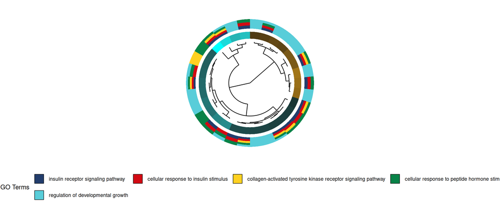

```r
# 定义颜色向量，用于后续可视化 | Define color palette for visualization
mycol <- c("#223D6C","#D20A13","#FFD121","#088247","#58CDD9","#7A142C","#5D90BA","#431A3D","#91612D","#6E568C","#E0367A","#D8D155","#64495D","#7CC767")

# 绘制基因富集聚类图 | Plot gene enrichment cluster diagram
GOCluster(circ.gsym, go$Term[1:n],              # 使用前n个富集的GO term | Use top n enriched GO terms
          clust.by = 'logFC',                   # 按表达量变化值聚类基因 | Cluster genes by log2 fold change
          #clust.by = 'term',                   # 按富集的term聚类基因(注释掉) | Cluster genes by enriched terms (commented out)
          lfc.col = c('darkgoldenrod1', 'black', 'cyan1'), # 自定义表达量变化的颜色映射 | Custom color palette for fold change
          lfc.space = 0.05,                     # 表达量变化与树形图之间的间距 | Space between fold change and tree
          lfc.width = 0.01,                     # 表达量变化圆圈的宽度 | Width of fold change circles
          term.col = mycol[1:n],                # 为每个term指定颜色 | Assign colors to terms
          term.space = 0.05,                    # term与表达量变化之间的间距 | Space between terms and fold change
          term.width = 0.15)                    # term圆圈的宽度 | Width of term circles
```

```r
# 将聚类图保存为PDF文件 | Save cluster diagram to PDF file
ggsave("GOCluster.pdf", width = 12, height = 14)
```